# Course Project - Shiny Application And Reproducable Pitch

2020-06-08

## About This Course Project

This project is part of the course; Developing Data Products which in turn is part of the Coursera Data Science Specialization.

The Instructions given for this project are as follows:

1. Write a shiny application with associated supporting documentation. The documentation should be thought of as whatever a user will need to get started using your application.
2. Deploy the application on Rstudio’s shiny server
3. Share the application link by pasting it into the provided text box
4. Share your server.R and ui.R code on github

## My Application Details

My application uses a public coronavirus data set located at the following link: https://www.ecdc.europa.eu/en/publications-data/download-todays-data-geographic-distribution-covid-19-cases-worldwide

This data is currently available as of 2020-06-08.

The application I have created allows the user to input any country from the dataset, along with a date range to produce a graph of deaths.

## Instructions for use

The app is hosted at the following link, https://smithy396.shinyapps.io/Shiny_Application/

The server, UI file & documentation are hosted on the following Github page https://github.com/Smithy396/Shiny-Application-and-Reproducible-Pitch

## An example graph showing United Kingdom Deaths

Below is an example using the same data set used within the app.

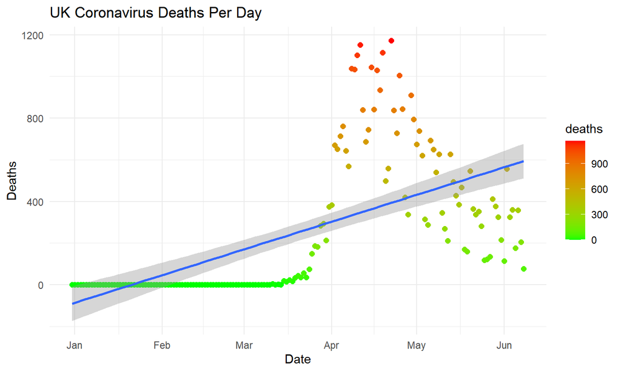